# An Analysis of Mono Lake Water Levels

Eva Wilson

11/28/2021

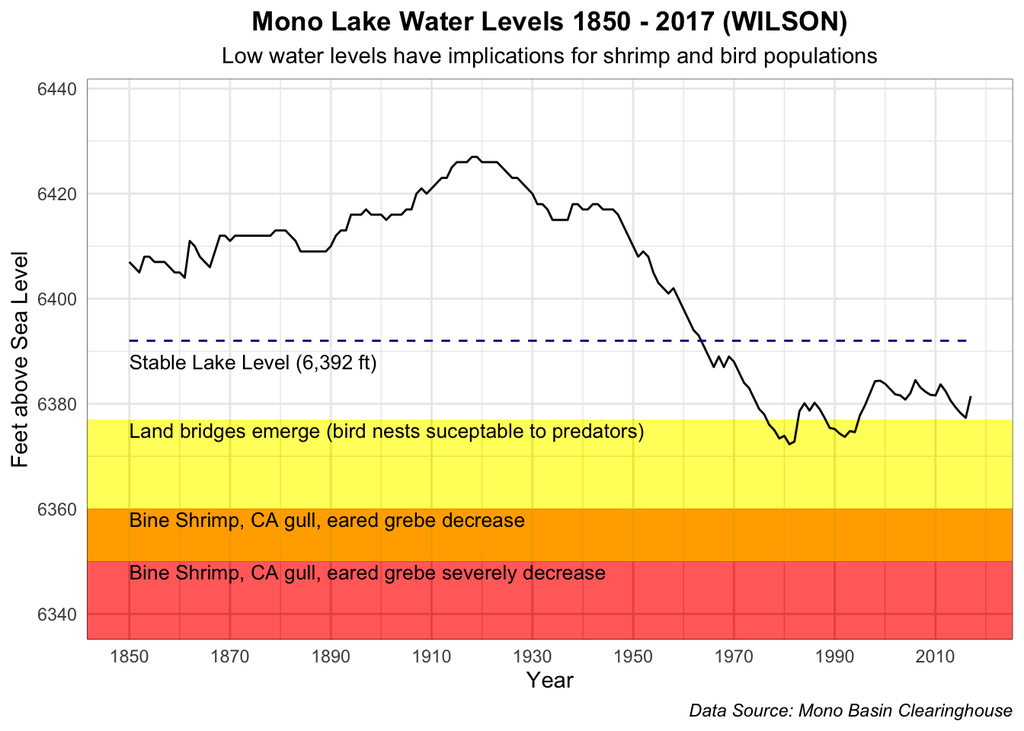

```r
# create a line graph depicting change in annual lake levels
ggplot(data = mono_lake, aes(x = year,
                             y = lake_level)) +
  geom_line(size = .5) +

# manually adjust axes
  scale_x_continuous(breaks = seq(1850, 2020, 20)) +
  ylim(6340, max(mono_lake$lake_level) + 10) +

# add graph features based on significant water levels
  geom_line(aes(x = year, y = stable_level),
            linetype = "dashed",
            color = "blue4") +
  geom_rect(aes(ymin = 6360, ymax = 6377,
                xmin = min(-Inf), xmax = max(Inf)),
            fill = "yellow",
            alpha = .005) +
  geom_rect(aes(ymin = 6350, ymax = 6360,
                xmin = min(-Inf), xmax = (Inf)),
            fill = "orange",
            alpha = .05) +
  geom_rect(aes(ymin = -Inf, ymax = 6350,
                xmin = (-Inf), xmax = (Inf)),
          fill = "red",
          alpha = .005) +

# label graph features
  annotate("text", x = 1850, y = 6388,
           label = "Stable Lake Level (6,392 ft)", size = 3.5, hjust = 0) +
  annotate("text", x = 1850, y = 6375,
           label = "Land bridges emerge (bird nests suceptable to predators)", size = 3.5, hjust = 0) +
  annotate("text", x = 1850, y = 6358,
           label = "Bine Shrimp, CA gull, eared grebe decrease",
           size = 3.5, hjust = 0) +
  annotate("text", x = 1850, y = 6348,
           label = "Bine Shrimp, CA gull, eared grebe severely decrease",
           size = 3.5, hjust = 0) +

# label axes and add title
  labs(x = "Year",
       y = "Feet above Sea Level",
       title = "Mono Lake Water Levels 1850 - 2017 (WILSON)",
       subtitle = "Low water levels have implications for shrimp and bird populations",
       caption = "Data Source: Mono Basin Clearinghouse") +

# adjust overall aesthetics
  theme_minimal() +
  theme(plot.title = element_text(hjust = 0.5, face = "bold")) +
  theme(plot.subtitle = element_text(hjust = 0.5)) +
  theme(strip.background = element_rect(color = "white", fill = "gray")) +
  theme(panel.border = element_rect(color = "black", fill = NA,
                                    size = 0.2)) +
  theme(plot.caption = element_text(hjust = 1, face = "italic"))
```

**Figure 1. Mono Lake Levels (1850-2017)** Depicts the change in water level (in feet above sea level) at Mono Lake, California. There is an overall decline in lake levels because water is diverted to Los Angeles for drinking. The maximum lake level is 6427 ft above sea level, and the minimum is 6372.3 ft above sea level. Stable lake levels, represented by the dashed blue line, are considered 6392 feet above sea level. Three water levels represent an issue for habitat health and bird populations. Starting at 6377 feet above sea level, or the area on the graph represented by the yellow rectangle, land bridges start to form. This can have an adverse affect on bird populations because predators can access their nesting sites. At 6360 feet, or the area on the graph represented by the orange rectangle, salinity levels in the lake are low enough (120 g/L) that they reduce food resources (Bine Shrimp populations) for eared grebes and California gulls. At 6350 feet above sea level, or the area on the graph represented by the red rectangle, salinity levels in the lake are considered acute (150 g/L) and therefore severely affact shrimp and bird populations.